# Cooccurance of Columbidae (based on worldwide records) and resulting urban tolerance

```r
library(dplyr)
library(tidyverse)
library(picante)
```

Load data for our columbidae species present in all localities of the world

```r
all_occurance = read_csv(gzfile('../../data/bigquery/columbidae_birdlife__worldwide_ebird_records.csv.gz'))
```

```r
head(all_occurance)
```

| scientific_name | locality_id | median_observation_count |
| --- | --- | --- |
| Columba albitorques | L5214462 | 70 |
| Columba guinea | L11543436 | 27 |
| Columba guinea | L11906800 | 40 |
| Columba guinea | L7116396 | 18 |
| Columba guinea | L9877712 | 34 |
| Columba leucomela | L10040206 | 31 |

```r
mapping = read_csv('../../data/bigquery/columbidae_birdlife_to_jetz__taxonomic_mapping.csv')
```

```r
all_occurance_jetz_pt1 = left_join(all_occurance, mapping, by = c("scientific_name" = "species_name"))
all_occurance_jetz = all_occurance_jetz_pt1 %>% group_by(locality_id, jetz_scientific_name) %>% summarise()
all_occurance_jetz
```

| locality_id | jetz_scientific_name |
| --- | --- |
| L1 | Columba_livia |
| L1 | Streptopelia_decaocto |
| L1 | Zenaida_macroura |
| L10 | Columba_livia |
| L10 | Zenaida_macroura |
| L10000000 | Ocyphaps_lophotes |
| L10000004 | Leptotila_verreauxi |
| L10000004 | Patagioenas_picazuro |
| L10000007 | Columba_livia |
| L10000007 | Streptopelia_decaocto |

[output cut: 990 more lines]

And then join to self using locality ID, which gives us all cooccuring species across the world, with urban tolerance.

```r
all_occurance_jetz2 = all_occurance_jetz
names(all_occurance_jetz2) = c('locality_id', 'jetz_scientific_name2')
cooccurance = right_join(all_occurance_jetz, all_occurance_jetz2)
cooccurance = cooccurance[cooccurance$jetz_scientific_name != cooccurance$jetz_scientific_name2,]
```

```r
head(cooccurance)
```

| locality_id | jetz_scientific_name | jetz_scientific_name2 |
| --- | --- | --- |
| L1 | Columba_livia | Streptopelia_decaocto |
| L1 | Columba_livia | Zenaida_macroura |
| L1 | Streptopelia_decaocto | Columba_livia |
| L1 | Streptopelia_decaocto | Zenaida_macroura |
| L1 | Zenaida_macroura | Columba_livia |
| L1 | Zenaida_macroura | Streptopelia_decaocto |

Remove locality so we end up with cooccuring species, along with number of patches recorded as cooccuring.

```r
cooccurance_details = cooccurance %>% group_by(jetz_scientific_name, jetz_scientific_name2) %>% summarise(recorded_patches = n())
cooccurance_details
```

| jetz_scientific_name | jetz_scientific_name2 | recorded_patches |
| --- | --- | --- |
| Alectroenas_madagascariensis | Columba_livia | 45 |
| Alectroenas_madagascariensis | Oena_capensis | 32 |
| Caloenas_nicobarica | Chalcophaps_indica | 61 |
| Caloenas_nicobarica | Columba_elphinstonii | 1 |
| Caloenas_nicobarica | Columba_livia | 24 |
| Caloenas_nicobarica | Columba_punicea | 1 |
| Caloenas_nicobarica | Columba_vitiensis | 10 |
| Caloenas_nicobarica | Ducula_aenea | 60 |
| Caloenas_nicobarica | Ducula_badia | 4 |
| Caloenas_nicobarica | Ducula_bicolor | 99 |

[output cut: 990 more lines]

Load in our regional pools

```r
regional_pools = read_csv('../../data/bigquery/columbidae_jetz__urban_locations.csv')
regional_pools = regional_pools[,c('jetz_scientific_name', 'city_id', 'present_in_city')]
head(regional_pools)
```

| jetz_scientific_name | city_id | present_in_city |
| --- | --- | --- |
| Stigmatopelia_chinensis | 1 | FALSE |
| Columbina_passerina | 514 | FALSE |
| Columbina_talpacoti | 514 | TRUE |
| Geotrygon_montana | 514 | FALSE |
| Claravis_mondetoura | 514 | FALSE |
| Leptotila_plumbeiceps | 514 | FALSE |

Generate all cooccuring species in regional pools

```r
regional_pools2 = regional_pools
names(regional_pools2) = c('jetz_scientific_name2', 'city_id', 'present_in_city2')
regional_cooccurance = right_join(regional_pools, regional_pools2)
regional_cooccurance = regional_cooccurance[regional_cooccurance$jetz_scientific_name != regional_cooccurance$jetz_scientific_name2,]
head(regional_cooccurance)
```

| jetz_scientific_name | city_id | present_in_city | jetz_scientific_name2 | present_in_city2 |
| --- | --- | --- | --- | --- |
| Columbina_passerina | 514 | FALSE | Columbina_talpacoti | TRUE |
| Columbina_passerina | 514 | FALSE | Geotrygon_montana | FALSE |
| Columbina_passerina | 514 | FALSE | Claravis_mondetoura | FALSE |
| Columbina_passerina | 514 | FALSE | Leptotila_plumbeiceps | FALSE |
| Columbina_passerina | 514 | FALSE | Leptotila_verreauxi | FALSE |
| Columbina_passerina | 514 | FALSE | Patagioenas_fasciata | FALSE |

```r
regional_cooccurance_pairs = regional_cooccurance %>% group_by(jetz_scientific_name, jetz_scientific_name2) %>% summarise(number_of_pools = n(), present_count = sum(present_in_city), present_count2 = sum(present_in_city2), both_present = sum(present_in_city & present_in_city2))
regional_cooccurance_pairs
```

| jetz_scientific_name | jetz_scientific_name2 | number_of_pools | present_count | present_count2 | both_present |
| --- | --- | --- | --- | --- | --- |
| Alectroenas_madagascariensis | Nesoenas_picturata | 1 | 0 | 0 | 0 |
| Aplopelia_larvata | Columba_albinucha | 1 | 0 | 0 | 0 |
| Aplopelia_larvata | Columba_albitorques | 1 | 0 | 1 | 0 |
| Aplopelia_larvata | Columba_arquatrix | 8 | 0 | 0 | 0 |
| Aplopelia_larvata | Columba_delegorguei | 2 | 0 | 0 | 0 |
| Aplopelia_larvata | Columba_guinea | 7 | 0 | 5 | 0 |
| Aplopelia_larvata | Oena_capensis | 8 | 0 | 0 | 0 |
| Aplopelia_larvata | Stigmatopelia_senegalensis | 9 | 0 | 0 | 0 |
| Aplopelia_larvata | Streptopelia_capicola | 7 | 0 | 5 | 0 |
| Aplopelia_larvata | Streptopelia_decipiens | 2 | 0 | 1 | 0 |

[output cut: 990 more lines]

Finally we can create all valid pairs of species that could be living in the same patches from our regional pools. Here we also drop all species where neither pair is present in the city

```r
regional_patch_cooccurance = right_join(regional_cooccurance_pairs, cooccurance_details)
regional_patch_cooccurance = regional_patch_cooccurance[!is.na(regional_patch_cooccurance$number_of_pools),]
regional_patch_cooccurance = regional_patch_cooccurance[regional_patch_cooccurance$present_count >= regional_patch_cooccurance$present_count2,]
regional_patch_cooccurance = regional_patch_cooccurance[regional_patch_cooccurance$present_count > 0,]
regional_patch_cooccurance
```

| jetz_scientific_name | jetz_scientific_name2 | number_of_pools | present_count | present_count2 | both_present | recorded_patches |
| --- | --- | --- | --- | --- | --- | --- |
| Chalcophaps_indica | Caloenas_nicobarica | 3 | 1 | 0 | 0 | 61 |
| Chalcophaps_indica | Columba_vitiensis | 2 | 1 | 0 | 0 | 214 |
| Chalcophaps_indica | Ducula_aenea | 41 | 2 | 2 | 0 | 2092 |
| Chalcophaps_indica | Ducula_badia | 30 | 1 | 0 | 0 | 1522 |
| Chalcophaps_indica | Ducula_bicolor | 7 | 2 | 2 | 1 | 299 |
| Chalcophaps_indica | Ducula_carola | 1 | 1 | 1 | 1 | 40 |
| Chalcophaps_indica | Ducula_poliocephala | 1 | 1 | 0 | 0 | 33 |
| Chalcophaps_indica | Gallicolumba_crinigera | 1 | 1 | 0 | 0 | 19 |
| Chalcophaps_indica | Macropygia_tenuirostris | 1 | 1 | 1 | 1 | 342 |
| Chalcophaps_indica | Phapitreron_amethystinus | 1 | 1 | 0 | 0 | 123 |

[output cut: 864 more lines]

In most of the records above, the number of times they are both present is the same that the number of times only the least dominant is presence. The exceptions are:

```r
regional_patch_cooccurance[regional_patch_cooccurance$present_count2 != regional_patch_cooccurance$both_present,]
```

| jetz_scientific_name | jetz_scientific_name2 | number_of_pools | present_count | present_count2 | both_present | recorded_patches |
| --- | --- | --- | --- | --- | --- | --- |
| Chalcophaps_indica | Ducula_aenea | 41 | 2 | 2 | 0 | 2092 |
| Chalcophaps_indica | Ducula_bicolor | 7 | 2 | 2 | 1 | 299 |
| Chalcophaps_indica | Ptilinopus_melanospilus | 3 | 1 | 1 | 0 | 218 |
| Chalcophaps_indica | Streptopelia_bitorquata | 4 | 1 | 1 | 0 | 122 |
| Chalcophaps_indica | Treron_bicinctus | 40 | 1 | 1 | 0 | 493 |
| Chalcophaps_indica | Treron_pompadora | 33 | 1 | 1 | 0 | 1901 |
| Columba_guinea | Treron_calvus | 8 | 6 | 1 | 0 | 939 |
| Columba_guinea | Turtur_tympanistria | 7 | 5 | 1 | 0 | 618 |
| Columba_oenas | Streptopelia_turtur | 97 | 22 | 3 | 0 | 4213 |
| Columba_palumbus | Streptopelia_turtur | 108 | 88 | 3 | 2 | 18815 |

[output cut: 108 more lines]

Problem records we have where they have the same tolerance (67 pairs of species):

```r
regional_patch_cooccurance[regional_patch_cooccurance$present_count == regional_patch_cooccurance$present_count2,]
```

| jetz_scientific_name | jetz_scientific_name2 | number_of_pools | present_count | present_count2 | both_present | recorded_patches |
| --- | --- | --- | --- | --- | --- | --- |
| Chalcophaps_indica | Ducula_aenea | 41 | 2 | 2 | 0 | 2092 |
| Chalcophaps_indica | Ducula_bicolor | 7 | 2 | 2 | 1 | 299 |
| Chalcophaps_indica | Ducula_carola | 1 | 1 | 1 | 1 | 40 |
| Chalcophaps_indica | Macropygia_tenuirostris | 1 | 1 | 1 | 1 | 342 |
| Chalcophaps_indica | Ptilinopus_melanospilus | 3 | 1 | 1 | 0 | 218 |
| Chalcophaps_indica | Streptopelia_bitorquata | 4 | 1 | 1 | 0 | 122 |
| Chalcophaps_indica | Treron_bicinctus | 40 | 1 | 1 | 0 | 493 |
| Chalcophaps_indica | Treron_curvirostra | 14 | 1 | 1 | 1 | 979 |
| Chalcophaps_indica | Treron_pompadora | 33 | 1 | 1 | 0 | 1901 |
| Columba_albitorques | Columba_guinea | 1 | 1 | 1 | 1 | 382 |

[output cut: 124 more lines]

Drop duplicate co-occuring pairs by creating a unique key from the two species names (should remove 67 rows)

```r
regional_patch_cooccurance = regional_patch_cooccurance %>% rowwise() %>%
  mutate(key = paste0(sort(c(jetz_scientific_name, jetz_scientific_name2)), collapse = '|'))

regional_patch_cooccurance = regional_patch_cooccurance[!duplicated(regional_patch_cooccurance$key),]

regional_patch_cooccurance
```

| jetz_scientific_name | jetz_scientific_name2 | number_of_pools | present_count | present_count2 | both_present | recorded_patches | key |
| --- | --- | --- | --- | --- | --- | --- | --- |
| Chalcophaps_indica | Caloenas_nicobarica | 3 | 1 | 0 | 0 | 61 | Caloenas_nicobarica\|Chalcophaps_indica |
| Chalcophaps_indica | Columba_vitiensis | 2 | 1 | 0 | 0 | 214 | Chalcophaps_indica\|Columba_vitiensis |
| Chalcophaps_indica | Ducula_aenea | 41 | 2 | 2 | 0 | 2092 | Chalcophaps_indica\|Ducula_aenea |
| Chalcophaps_indica | Ducula_badia | 30 | 1 | 0 | 0 | 1522 | Chalcophaps_indica\|Ducula_badia |
| Chalcophaps_indica | Ducula_bicolor | 7 | 2 | 2 | 1 | 299 | Chalcophaps_indica\|Ducula_bicolor |
| Chalcophaps_indica | Ducula_carola | 1 | 1 | 1 | 1 | 40 | Chalcophaps_indica\|Ducula_carola |
| Chalcophaps_indica | Ducula_poliocephala | 1 | 1 | 0 | 0 | 33 | Chalcophaps_indica\|Ducula_poliocephala |
| Chalcophaps_indica | Gallicolumba_crinigera | 1 | 1 | 0 | 0 | 19 | Chalcophaps_indica\|Gallicolumba_crinigera |
| Chalcophaps_indica | Macropygia_tenuirostris | 1 | 1 | 1 | 1 | 342 | Chalcophaps_indica\|Macropygia_tenuirostris |
| Chalcophaps_indica | Phapitreron_amethystinus | 1 | 1 | 0 | 0 | 123 | Chalcophaps_indica\|Phapitreron_amethystinus |

[output cut: 797 more lines]

Work out MNTD between each species pair:

```r
tree <- read.tree("../../data/third_party/phylogeny_jetz__stage2_hackett_mcc_no_neg.tre")
```

```r
all_species = unique(c(regional_patch_cooccurance$jetz_scientific_name, regional_patch_cooccurance$jetz_scientific_name2))
tree_pruned_to_columbidae <- ladderize(drop.tip(tree, setdiff(tree$tip.label, all_species)))
```

```r
phydist <- cophenetic(tree_pruned_to_columbidae)
```

```r
regional_patch_cooccurance$mntd = NA

for(row_i in 1:nrow(regional_patch_cooccurance)) {
  community = data.frame(species1 = c(T, T), species2 = c(T, T))
  names(community) = list(as.character(regional_patch_cooccurance[[ row_i,c('jetz_scientific_name')]]), as.character(regional_patch_cooccurance[[ row_i,c('jetz_scientific_name2')]]))
  rownames(community) = c('1', '2')

  mntd.community.result <- ses.mntd(as.matrix(community), phydist, null.model="taxa.labels", abundance.weighted=FALSE, runs=99)

  regional_patch_cooccurance[row_i,]$mntd = mntd.community.result[1,]$mntd.obs
}

regional_patch_cooccurance
```

| jetz_scientific_name | jetz_scientific_name2 | number_of_pools | present_count | present_count2 | both_present | recorded_patches | key | mntd |
| --- | --- | --- | --- | --- | --- | --- | --- | --- |
| Chalcophaps_indica | Caloenas_nicobarica | 3 | 1 | 0 | 0 | 61 | Caloenas_nicobarica\|Chalcophaps_indica | 55.945606 |
| Chalcophaps_indica | Columba_vitiensis | 2 | 1 | 0 | 0 | 214 | Chalcophaps_indica\|Columba_vitiensis | 60.172908 |
| Chalcophaps_indica | Ducula_aenea | 41 | 2 | 2 | 0 | 2092 | Chalcophaps_indica\|Ducula_aenea | 54.619228 |
| Chalcophaps_indica | Ducula_badia | 30 | 1 | 0 | 0 | 1522 | Chalcophaps_indica\|Ducula_badia | 54.619228 |
| Chalcophaps_indica | Ducula_bicolor | 7 | 2 | 2 | 1 | 299 | Chalcophaps_indica\|Ducula_bicolor | 54.619228 |
| Chalcophaps_indica | Ducula_carola | 1 | 1 | 1 | 1 | 40 | Chalcophaps_indica\|Ducula_carola | 54.619228 |
| Chalcophaps_indica | Ducula_poliocephala | 1 | 1 | 0 | 0 | 33 | Chalcophaps_indica\|Ducula_poliocephala | 54.619228 |
| Chalcophaps_indica | Gallicolumba_crinigera | 1 | 1 | 0 | 0 | 19 | Chalcophaps_indica\|Gallicolumba_crinigera | 57.397035 |
| Chalcophaps_indica | Macropygia_tenuirostris | 1 | 1 | 1 | 1 | 342 | Chalcophaps_indica\|Macropygia_tenuirostris | 60.172908 |
| Chalcophaps_indica | Phapitreron_amethystinus | 1 | 1 | 0 | 0 | 123 | Chalcophaps_indica\|Phapitreron_amethystinus | 55.210842 |

[output cut: 797 more lines]

Calculate a status which indicates whether species are in the city together:

```r
regional_patch_cooccurance$cooccurance_status = 'Occasional'
regional_patch_cooccurance$cooccurance_status[regional_patch_cooccurance$present_count2 == 0] = 'Never'
regional_patch_cooccurance$cooccurance_status[regional_patch_cooccurance$present_count == regional_patch_cooccurance$present_count2] = 'Always'

regional_patch_cooccurance
```

| jetz_scientific_name | jetz_scientific_name2 | number_of_pools | present_count | present_count2 | both_present | recorded_patches | key | mntd | cooccurance_status |
| --- | --- | --- | --- | --- | --- | --- | --- | --- | --- |
| Chalcophaps_indica | Caloenas_nicobarica | 3 | 1 | 0 | 0 | 61 | Caloenas_nicobarica\|Chalcophaps_indica | 55.945606 | Never |
| Chalcophaps_indica | Columba_vitiensis | 2 | 1 | 0 | 0 | 214 | Chalcophaps_indica\|Columba_vitiensis | 60.172908 | Never |
| Chalcophaps_indica | Ducula_aenea | 41 | 2 | 2 | 0 | 2092 | Chalcophaps_indica\|Ducula_aenea | 54.619228 | Always |
| Chalcophaps_indica | Ducula_badia | 30 | 1 | 0 | 0 | 1522 | Chalcophaps_indica\|Ducula_badia | 54.619228 | Never |
| Chalcophaps_indica | Ducula_bicolor | 7 | 2 | 2 | 1 | 299 | Chalcophaps_indica\|Ducula_bicolor | 54.619228 | Always |
| Chalcophaps_indica | Ducula_carola | 1 | 1 | 1 | 1 | 40 | Chalcophaps_indica\|Ducula_carola | 54.619228 | Always |
| Chalcophaps_indica | Ducula_poliocephala | 1 | 1 | 0 | 0 | 33 | Chalcophaps_indica\|Ducula_poliocephala | 54.619228 | Never |
| Chalcophaps_indica | Gallicolumba_crinigera | 1 | 1 | 0 | 0 | 19 | Chalcophaps_indica\|Gallicolumba_crinigera | 57.397035 | Never |
| Chalcophaps_indica | Macropygia_tenuirostris | 1 | 1 | 1 | 1 | 342 | Chalcophaps_indica\|Macropygia_tenuirostris | 60.172908 | Always |
| Chalcophaps_indica | Phapitreron_amethystinus | 1 | 1 | 0 | 0 | 123 | Chalcophaps_indica\|Phapitreron_amethystinus | 55.210842 | Never |

[output cut: 797 more lines]

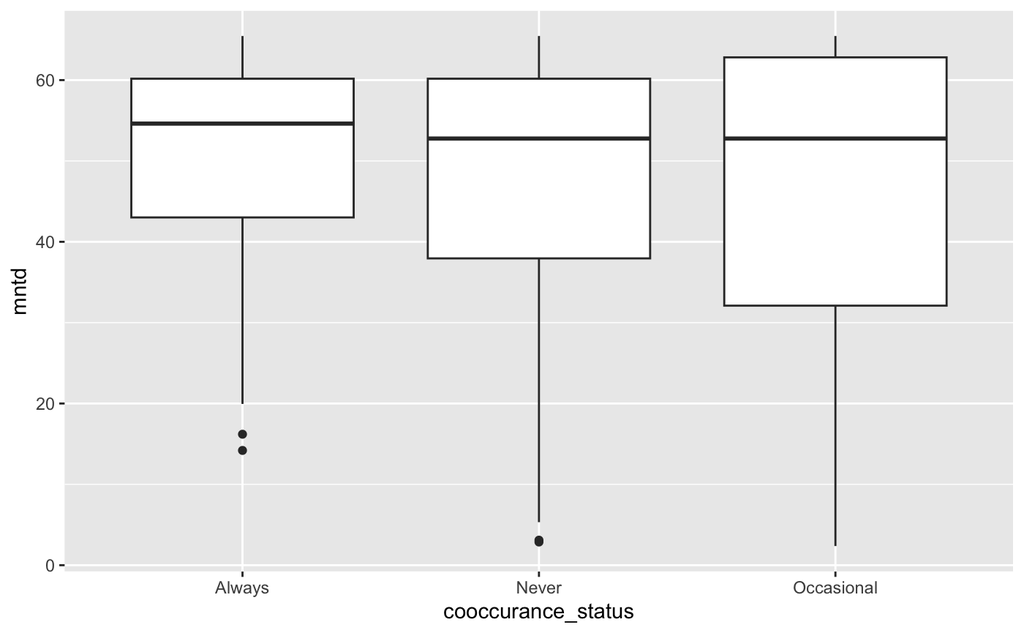

```r
ggplot(regional_patch_cooccurance, aes(x = cooccurance_status, y = mntd)) + geom_boxplot()
```

```r
shapiro.test(regional_patch_cooccurance$mntd)
```

```
    Shapiro-Wilk normality test

data:  regional_patch_cooccurance$mntd
W = 0.86167, p-value < 2.2e-16
```

```r
shapiro.test(log(regional_patch_cooccurance$mntd))
```

```
    Shapiro-Wilk normality test

data:  log(regional_patch_cooccurance$mntd)
W = 0.72374, p-value < 2.2e-16
```

```r
shapiro.test(sqrt(regional_patch_cooccurance$mntd))
```

```
    Shapiro-Wilk normality test

data:  sqrt(regional_patch_cooccurance$mntd)
W = 0.81812, p-value < 2.2e-16
```

```r
nrow(regional_patch_cooccurance)
```

```
[1] 807
```

```r
mean(regional_patch_cooccurance$mntd)
```

```
[1] 49.07858
```

```r
regional_patch_cooccurance %>% group_by(cooccurance_status) %>% summarise(mean = mean(mntd), sd = sd(mntd), min = min(mntd), max = max(mntd), total = n())
```

| cooccurance_status | mean | sd | min | max | total |
| --- | --- | --- | --- | --- | --- |
| Always | 51.26656 | 14.44143 | 14.195903 | 65.45357 | 67 |
| Never | 49.40871 | 15.47570 | 2.868878 | 65.45357 | 573 |
| Occasional | 47.06808 | 19.18623 | 2.369834 | 65.45357 | 167 |

```r
t.test(regional_patch_cooccurance$mntd[regional_patch_cooccurance$cooccurance_status == 'Never'], regional_patch_cooccurance$mntd[regional_patch_cooccurance$cooccurance_status == 'Always'])
```

```
    Welch Two Sample t-test

data:  regional_patch_cooccurance$mntd[regional_patch_cooccurance$cooccurance_status == "Never"] and regional_patch_cooccurance$mntd[regional_patch_cooccurance$cooccurance_status == "Always"]
t = -0.98873, df = 84.738, p-value = 0.3256
alternative hypothesis: true difference in means is not equal to 0
95 percent confidence interval:
 -5.594023  1.878317
sample estimates:
mean of x mean of y
 49.40871  51.26656
```

```r
kruskal.test(cooccurance_status ~ mntd, data = regional_patch_cooccurance)
```

[output not shown]

# Map Co-occurance using a network plot

## All co-occurance

```r
library(GGally)
```

```r
regional_patch_cooccurance
```

| jetz_scientific_name | jetz_scientific_name2 | number_of_pools | present_count | present_count2 | both_present | recorded_patches | key | mntd | cooccurance_status |
| --- | --- | --- | --- | --- | --- | --- | --- | --- | --- |
| Chalcophaps_indica | Caloenas_nicobarica | 3 | 1 | 0 | 0 | 61 | Caloenas_nicobarica\|Chalcophaps_indica | 55.945606 | Never |
| Chalcophaps_indica | Columba_vitiensis | 2 | 1 | 0 | 0 | 214 | Chalcophaps_indica\|Columba_vitiensis | 60.172908 | Never |
| Chalcophaps_indica | Ducula_aenea | 41 | 2 | 2 | 0 | 2092 | Chalcophaps_indica\|Ducula_aenea | 54.619228 | Always |
| Chalcophaps_indica | Ducula_badia | 30 | 1 | 0 | 0 | 1522 | Chalcophaps_indica\|Ducula_badia | 54.619228 | Never |
| Chalcophaps_indica | Ducula_bicolor | 7 | 2 | 2 | 1 | 299 | Chalcophaps_indica\|Ducula_bicolor | 54.619228 | Always |
| Chalcophaps_indica | Ducula_carola | 1 | 1 | 1 | 1 | 40 | Chalcophaps_indica\|Ducula_carola | 54.619228 | Always |
| Chalcophaps_indica | Ducula_poliocephala | 1 | 1 | 0 | 0 | 33 | Chalcophaps_indica\|Ducula_poliocephala | 54.619228 | Never |
| Chalcophaps_indica | Gallicolumba_crinigera | 1 | 1 | 0 | 0 | 19 | Chalcophaps_indica\|Gallicolumba_crinigera | 57.397035 | Never |
| Chalcophaps_indica | Macropygia_tenuirostris | 1 | 1 | 1 | 1 | 342 | Chalcophaps_indica\|Macropygia_tenuirostris | 60.172908 | Always |
| Chalcophaps_indica | Phapitreron_amethystinus | 1 | 1 | 0 | 0 | 123 | Chalcophaps_indica\|Phapitreron_amethystinus | 55.210842 | Never |

[output cut: 797 more lines]

```r
regional_patch_cooccurance$number_of_pools_sqrt = as.integer(sqrt(regional_patch_cooccurance$number_of_pools))
regional_patch_cooccurance$cooccurance_ratio = regional_patch_cooccurance$both_present / regional_patch_cooccurance$number_of_pools

cooccurance_ratio_color_ramp <- colorRampPalette(c("red", "blue"))
cooccurance_ratio_palette = cooccurance_ratio_color_ramp(11)

get_ratio_colour = function(ratio) {
  cooccurance_ratio_palette[round(ratio * 10)]
}

color.gradient <- function(x, colors=c("red","yellow", "green"), colsteps=100) {
  return( colorRampPalette(colors) (colsteps) [ findInterval(x, seq(min(x),max(x), length.out=colsteps)) ] )
}

regional_patch_cooccurance$cooccurance_ratio_colour = color.gradient(regional_patch_cooccurance$cooccurance_ratio)
```

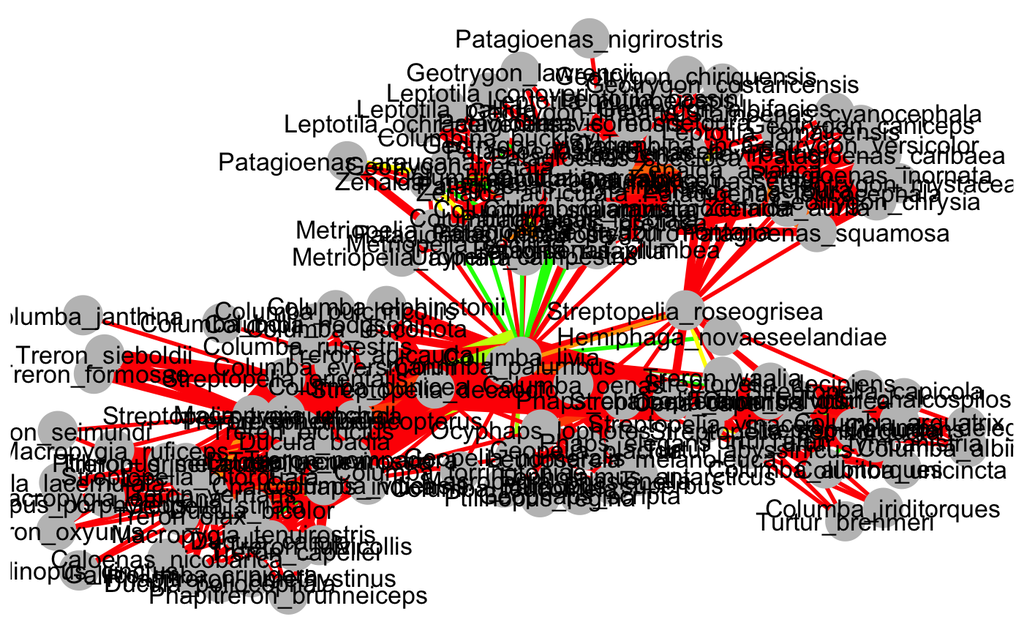

```r
ggnet2(regional_patch_cooccurance, label = T, edge.size = "number_of_pools_sqrt", edge.color = "cooccurance_ratio_colour", legend.position = "bottom")
```

```r
jpeg("figures/worldwide_cooccurance.jpg", width=5112, height=5112)
ggnet2(regional_patch_cooccurance, label = T, edge.size = "number_of_pools_sqrt", edge.color = "cooccurance_ratio_colour")
dev.off()
```

## Cooccurrance by realm

[output not shown]

```r
cities_to_realms = read_csv('../../data/earth_engine/cities_to_realms.csv')
names(cities_to_realms) = c('city_id', 'realm')
head(cities_to_realms)
```

| city_id | realm |
| --- | --- |
| 69 | Indomalayan |
| 70 | Indomalayan |
| 71 | Nearctic |
| 72 | Nearctic |
| 72 | Neotropic |
| 73 | Indomalayan |

[output not shown]

[output cut: 109 more lines]